# UNICEF Report

The First Battle of Life

Author

Léa CLERGEAUD

Published

April 28, 2025

According to **UNICEF**, neonatal deaths refer to **the loss of newborns within their first 28 days of life**. These early deaths are often preventable with access to quality healthcare, proper nutrition, and improved living conditions. Every year, millions of newborns face a life-or-death battle. **Since 1960, over 220 million infants have tragically lost this battle - a number comparable to the entire population of Brazil.**

## **A global perspective**

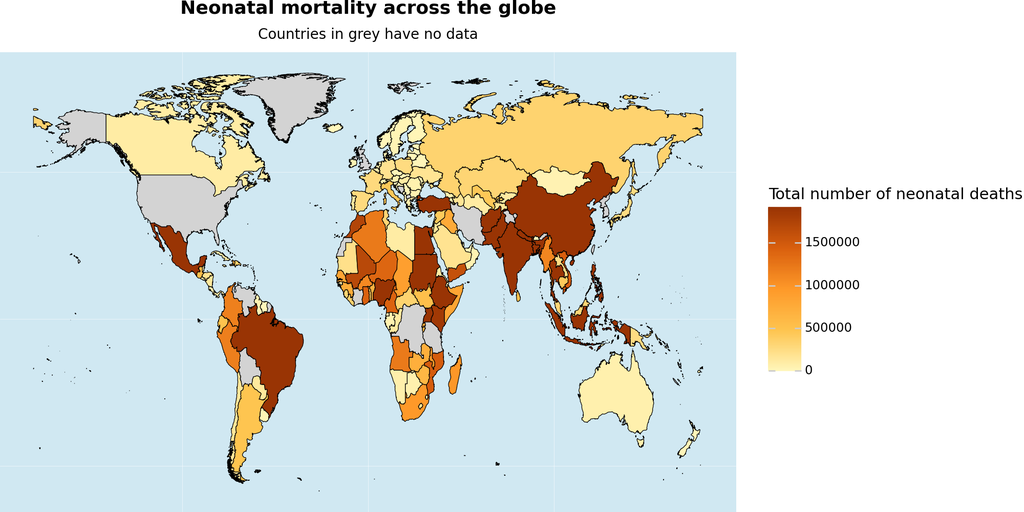

**Every newborn’s first breath should be a promise of life — but around the world, this promise is not equally kept.**

The map highlights that there is a particularly **high concentration across Sub-Saharan Africa and South Asia**, notably in India, Pakistan, and Bangladesh. These regions are characterized by limited access to maternal and newborn healthcare, under-resourced health systems, and significant economic inequalities.

This **uneven distribution** underscores the urgent need for targeted investments to improve newborn survival in the world’s most vulnerable areas.

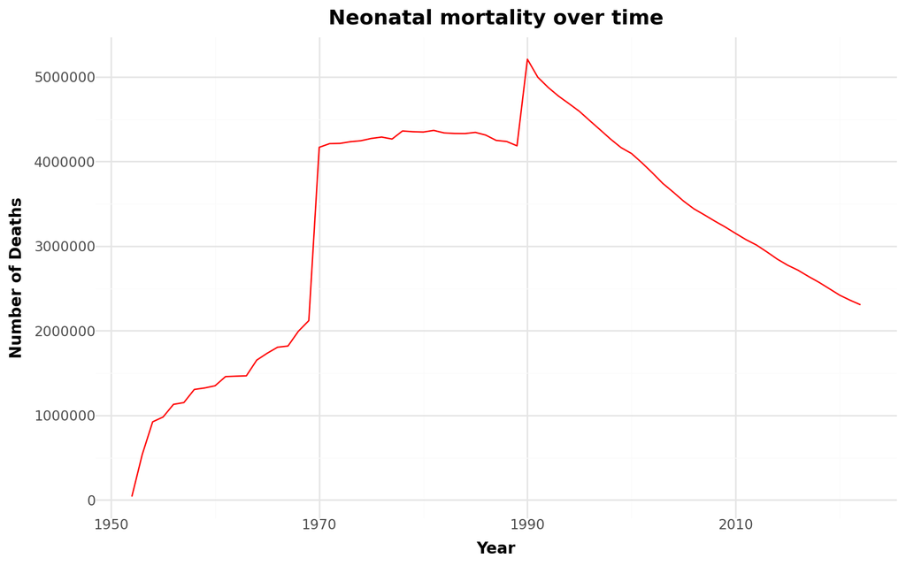

The graph shows the evolution of neonatal mortality from the 1950s to the 2020s. We observe a sharp increase in the number of neonatal deaths during the 1960s and 1970s, reaching a peak around the late 1980s and early 1990s. This rise is historically linked to multiple factors:

1. **Rapid population growth**: During the post-World War II period (the “baby boom”), especially in low- and middle-income countries, birth rates exploded. According to Our World in Data, the global population doubled between 1950 and 1987, naturally increasing the absolute number of neonatal deaths even if mortality rates per 1,000 births remained stable or decreased slowly.
2. **Limited access to healthcare**: In many parts of Africa and South Asia, healthcare systems were overwhelmed or underdeveloped during these decades. Neonatal care units, vaccination programs, and prenatal care were scarce or inaccessible for most of the population.

1. **Expanded immunization programs**: Initiatives such as the WHO’s Expanded Program on Immunization (launched in 1974) started to show strong results by the 1990s, drastically reducing infections that often caused neonatal deaths.
2. **Global health funding**: The 1990s and early 2000s saw a surge in international investments (e.g., GAVI, UNICEF, World Bank initiatives) that improved access to maternal and newborn healthcare, particularly in rural areas.
3. **MDGs impact**: The Millennium Development Goals (2000-2015) placed strong emphasis on neonatal and maternal health (MDG5), catalyzing efforts that continued the downward trend.

Despite the decline, the number of neonatal deaths remains a major concern today, particularly in the most vulnerable regions.

## **Two Worlds of Neonatal Survival**

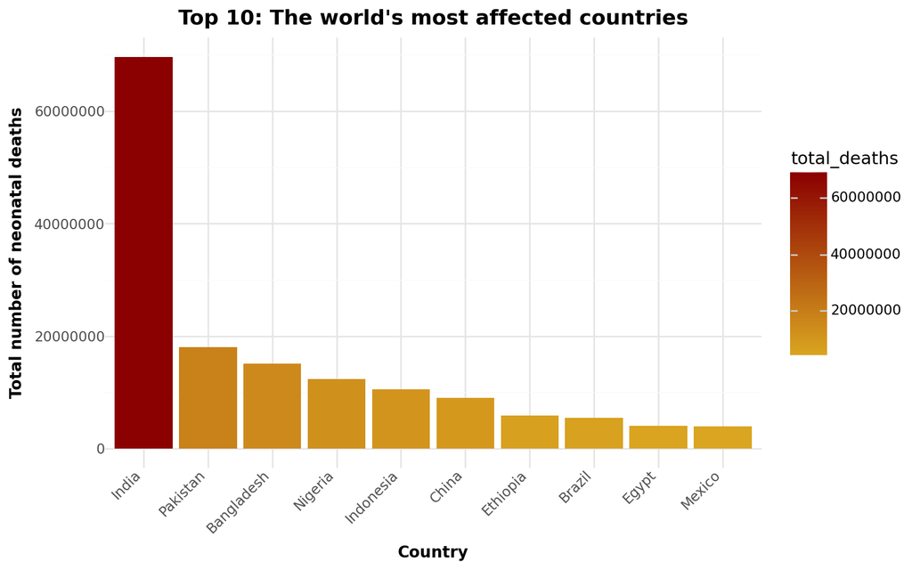

Populous nations like India, Nigeria, and Pakistan experience devastatingly high neonatal deaths. For instance, **India alone recorded over 1.9 million neonatal deaths in 1974**. This is often linked to large populations, high birth rates, and limited healthcare infrastructure.

Other countries such as Bangladesh, Indonesia, China, Ethiopia, Brazil, Egypt, and Mexico also rank among the top 10. Although their numbers are lower, they still reflect persistent challenges, especially in ensuring equal access to maternal and newborn care across regions.

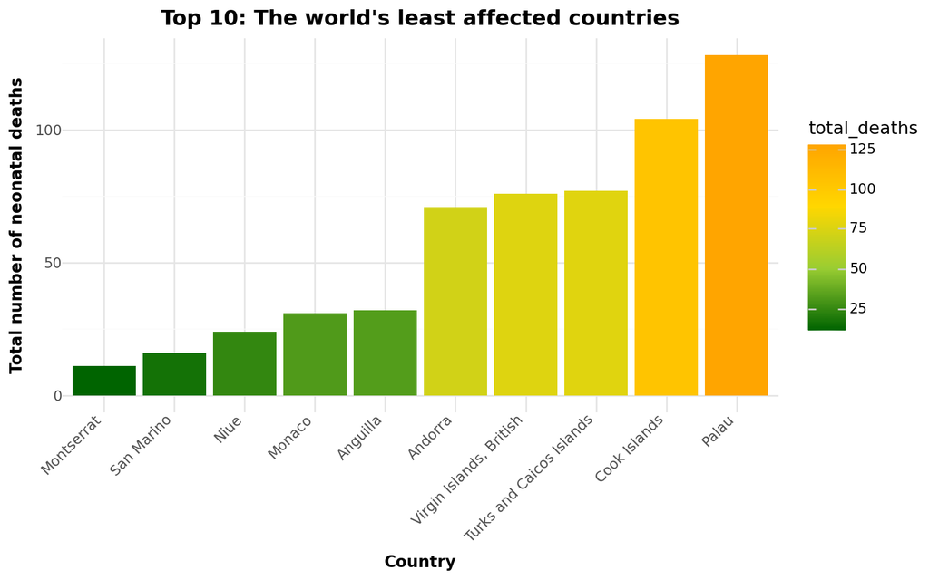

**While populous countries bear the highest burden of neonatal deaths, smaller nations show the opposite trend.** Territories like Montserrat, San Marino, Niue, and Monaco recorded the fewest neonatal deaths over the entire period. Most of these countries have small populations, strong healthcare systems, and generally high standards of living, which contribute to better outcomes for newborns.

Interestingly, even among these least affected countries, the total number of deaths rarely exceeds a few dozen to a hundred, highlighting how population scale and resources play a major role in neonatal survival.

## **As wealth rises, neonatal deaths fall**

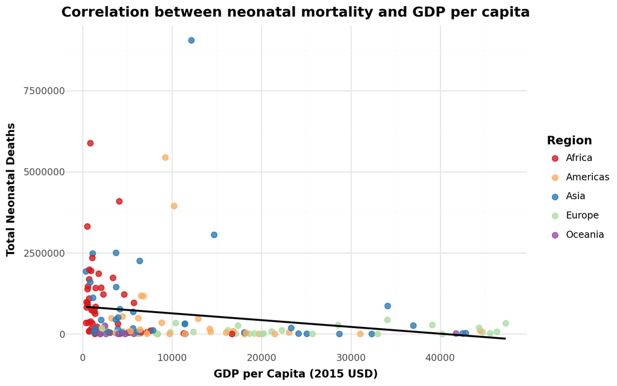

The scatter plot shows a clear trend: as a country’s wealth increases, neonatal deaths tend to decrease. Countries with low GDP per capita, especially in Africa and parts of Asia, record significantly higher numbers of neonatal deaths. Meanwhile, nations with higher incomes, mostly in Europe and Oceania, have much lower totals.

This highlights how **economic development is strongly tied to healthcare access, quality of maternal care, and better survival chances for newborns**.

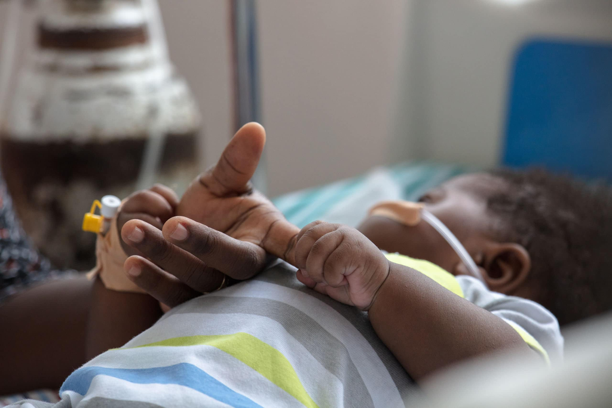

## **Regional disparities**

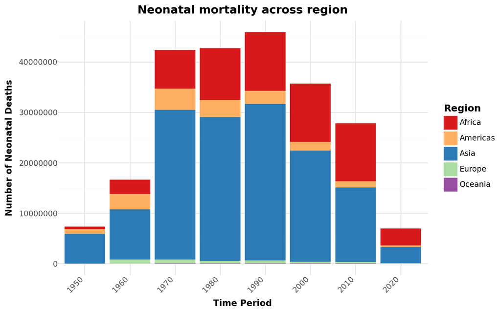

**Neonatal mortality patterns have evolved significantly over the past decades.**

Overall, the global trend highlights that **progress is possible** — and that with continued efforts, even the regions still facing high neonatal mortality can see significant improvements in the years ahead.

## **Conclusion: Neonatal mortality is not just a health issue, it is a reflection of global inequality**

This report has revealed how a newborn’s chance of survival is shaped by income, healthcare access, and living conditions. Countries with stronger systems report lower neonatal detahs, while under-ressourced regions continue to suffer avoidable losses. **This is not just a tragedy, it’s an opportunity.** With the right investments and support, millions of newborn lives can be saved. If you’d like to take actions, please consider donating here.